# MTB Categorization Analysis

# Introduction

For this project, our team will determine whether the specifications of mountain bikes (MTB) are enough to differentiate between the different types of mountain bike categories.

Currently, full suspension mountain bikes come in multiple categories:

- **Cross Country (XC)** | Tend to be the most lightweight, nimble, and designed to put the rider in an efficient pedaling position
- **Enduro** | Heavier frames, more travel and more downhill oriented geometry
- **Trail** | The most common category of bikes, considered to be the halfway point between XC and Enduro
- **All Mountain** | A more niche category which some manufacturers claim to be more downhill focused than trail bikes, but not designed for downhill races like Enduro bikes are
- **Downcountry** | A relatively new category between XC and Trail. Similar to the All Mountain category, these bikes aren’t race specific like XC bikes tend to be, but are lighter and faster than trail bikes.

With all of the factors to consider when designing a bike, there are no clear boundaries between these categories. For example, one brand’s Downcountry bike could be what another brand considers a Trail bike.

**The goal of our project is to determine how many, if any, discrete categories should exist for mountain bikes.** Since most specifications and geometric measurements have one direction when moving across the spectrum of bikes, it’s reasonable to believe that these measurements could be reduced to much fewer dimensions, and perhaps even one continuous principle component rather than discrete categories. Here is a diagram of some of the different types of geometric specifications on mountain bikes:

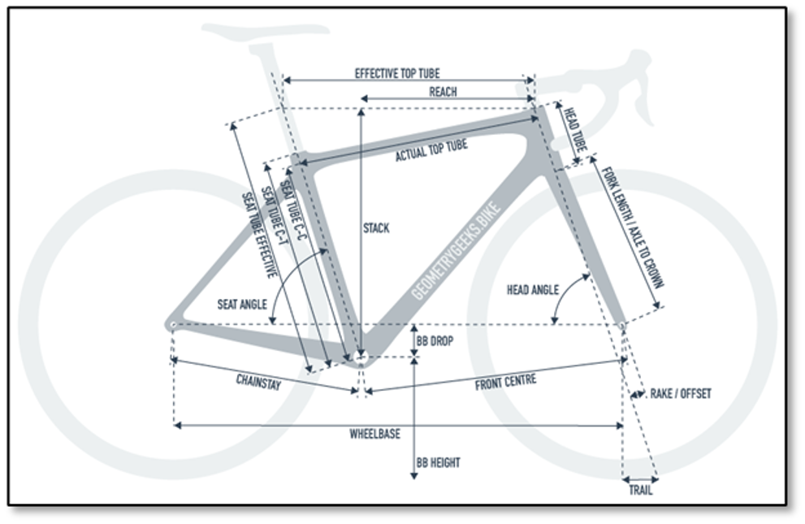

Various Dimension Features of a Bike’s Geometry

Let’s start by taking a look at the data.

```r
# Read in sheet 2 of our data
mtb_data <- read_excel(here::here('Data/mtb_stats.xlsx'), 'Sheet1')
mtb_data <- mtb_data %>%
  # Clean up the label column
  mutate(label = str_replace_all(str_to_lower(label), '[:punct:]', ''))

# Pull out the class labels
labels <- mtb_data %>%
  select(label)


# Let's view the mtb_data output
# In any kable outputs, display NAs as blanks
opts <- options(knitr.kable.NA = "")

mtb_data %>%
  head(25) %>%
  # Fix up the headers by replacing the underscores with spaces
  rename_all(funs(str_replace_all(., "_", " "))) %>%
  # Make everything proper capitalization
  # rename_all(funs(str_to_title)) %>%
  kable() %>%
  kable_styling(bootstrap_options = c("striped", "hover"),
                full_width = F,
                font_size = 12) %>%
  # Make the header row bold and black so it's easier to read
  row_spec(0, bold = T, color = "black") %>%
  scroll_box(height = "400px", width = "100%")
```

| url | model | brand | build type | price | image | setting | size used | label | rear travel | fork travel | f piston | f rotor dim | r piston | r rotor dim | head angle | seat angle | crank length | stem length | handlebar width | reach | stack | wheelbase | chainstay length | bb height | standover height |
| --- | --- | --- | --- | --- | --- | --- | --- | --- | --- | --- | --- | --- | --- | --- | --- | --- | --- | --- | --- | --- | --- | --- | --- | --- | --- |
|  | habit | cannondale |  |  |  |  | L | tr | 130 | 140 |  | 180 |  | 180 | 66.0 | 74.5 |  |  | 780 | 460.0 | 625.0 | 1210.0 | 435.0 | 339.0 | 770.0 |
|  | scalpel | cannondale |  |  |  |  | L | xc | 100 | 100 |  | 160 |  | 160 | 68.0 | 74.5 |  | 80 | 760 | 435.0 | 601.0 | 1175.0 | 436.0 | 331.0 | 745.0 |
|  | scalpel se | cannondale |  |  |  |  | L | dc | 120 | 120 |  | 160 |  | 160 | 67.0 | 74.0 |  |  | 780 | 450.0 | 611.0 | 1172.0 | 436.0 | 344.0 | 758.0 |
|  | reign advanced pro | giant |  |  |  |  | L | en | 146 | 170 | 4 | 203 | 4 | 203 | 64.6 | 76.4 |  | 40 | 800 | 488.0 | 631.0 | 1262.0 | 439.0 |  | 781.0 |
|  | trance advanced X pro | giant |  |  |  | high | L | tr | 135 | 150 | 4 | 203 | 4 | 180 | 66.2 | 77.9 |  | 50 | 800 | 494.0 | 624.0 | 1238.0 | 435.0 |  | 761.0 |
|  | trance advanced X pro | giant |  |  |  | low | L | tr | 135 | 150 | 4 | 203 | 4 | 180 | 65.5 | 77.2 |  | 50 | 800 | 486.0 | 631.0 | 1239.0 | 438.0 |  | 752.0 |
|  | anthem advanced pro | giant |  |  |  |  | L | xc | 90 | 100 |  | 180 |  | 160 | 69.0 | 73.5 |  | 80 | 780 | 454.0 | 594.0 | 1154.0 | 438.0 |  | 817.0 |
|  | jet 9 rdo | niner |  |  |  | high | M | tr | 120 | 130 |  | 180 |  | 180 | 66.5 | 76.0 |  | 40 | 800 | 450.0 | 613.0 | 1179.0 | 430.0 |  | 698.0 |
|  | jet 9 rdo | niner |  |  |  | low | M | tr | 120 | 130 |  | 180 |  | 180 | 66.0 | 75.5 |  | 40 | 800 | 444.0 | 617.0 | 1180.0 | 432.0 |  | 705.0 |
|  | rip 0 rdo | niner |  |  |  | high | M | tr | 140 | 150 |  | 180 |  | 180 | 66.0 | 75.8 |  |  | 800 | 440.0 | 615.0 | 1181.0 | 435.0 |  | 712.0 |
|  | rip 0 rdo | niner |  |  |  | low | M | tr | 140 | 150 |  | 180 |  | 180 | 65.0 | 75.2 |  |  | 800 | 433.0 | 619.0 | 1182.0 | 435.0 |  | 705.0 |
|  | rkt 9 rdo | niner |  |  |  |  | M | dc | 90 | 120 |  | 180 |  | 160 | 70.0 | 73.5 |  |  | 780 | 413.0 | 617.0 | 1111.0 | 439.0 |  | 739.0 |
|  | rkt 9 rdo rs | niner |  |  |  |  | M | xc | 90 | 100 |  | 180 |  | 160 | 71.0 | 74.5 |  |  | 780 | 424.0 | 600.0 | 1103.0 | 439.0 |  | 728.0 |
|  | megatower | santa cruz |  |  |  |  | L | en | 160 | 160 |  | 200 |  | 200 | 65.0 | 76.6 |  |  |  | 470.0 | 625.0 | 1231.0 | 435.0 | 343.0 | 713.0 |
|  | tallboy | santa cruz |  |  |  |  | L | tr | 120 | 130 |  | 180 |  | 180 | 65.7 | 76.4 |  | 50 | 800 | 470.0 | 619.0 | 1211.0 | 430.0 | 335.0 | 706.0 |
|  | hightower | santa cruz |  |  |  |  | L | tr | 145 | 150 |  | 180 |  | 180 | 65.5 | 76.8 |  | 50 | 780 | 473.0 | 619.0 | 1231.0 | 433.0 | 344.0 | 717.0 |
|  | blur | santa cruz |  |  |  |  | L | xc | 100 | 100 |  | 160 |  | 160 | 69.0 | 74.0 |  |  | 750 | 460.0 | 598.0 | 1160.0 | 432.0 | 328.0 | 723.0 |
|  | blur tr | santa cruz |  |  |  |  | L | dc | 115 | 120 | 2 | 180 | 2 | 180 | 67.1 | 74.9 | 175 | 60 | 760 | 457.5 | 606.5 | 1183.2 | 435.8 | 339.6 | 745.4 |
|  | ransom | scott |  |  |  |  | L/29 | en | 170 | 170 | 4 | 203 | 4 | 180 | 64.5 | 75.0 |  | 50 | 800 | 466.5 | 627.6 | 1249.2 | 437.9 | 353.0 | 760.9 |
|  | spark | scott |  |  |  |  | L | tr | 120 | 130 |  | 180 |  | 180 | 67.2 | 73.8 |  | 70 | 760 | 460.0 | 602.4 | 1182.8 | 438.0 | 327.0 | 778.0 |
|  | genius | scott |  |  |  | high | L | tr | 150 | 150 |  | 203 |  | 180 | 65.6 | 75.3 |  | 50 | 780 | 472.0 | 609.2 | 1230.8 | 436.0 | 340.0 | 749.5 |
|  | genius | scott |  |  |  | low | L | tr | 150 | 150 |  | 203 |  | 180 | 65.0 | 74.8 |  | 50 | 780 | 466.1 | 613.7 | 1232.1 | 438.0 | 345.9 | 758.4 |
|  | spark rc | scott |  |  |  |  | L | xc | 100 | 110 |  | 180 |  | 160 | 68.5 | 73.8 |  | 80 | 740 | 456.8 | 596.2 | 1158.6 | 435.0 | 319.5 | 756.0 |
|  | epic evo | specialized |  |  |  | high | m | dc | 110 | 120 | 4 | 180 | 4 | 160 | 67.0 | 74.5 | 175 | 60 | 760 | 436.0 | 597.0 | 1164.0 | 438.0 | 339.0 | 781.0 |
|  | epic evo | specialized |  |  |  | low | m | dc | 110 | 120 | 4 | 180 | 4 | 160 | 66.5 | 74.5 | 175 | 60 | 760 | 436.0 | 597.0 | 1164.0 | 438.0 | 336.0 | 781.0 |

# EDA

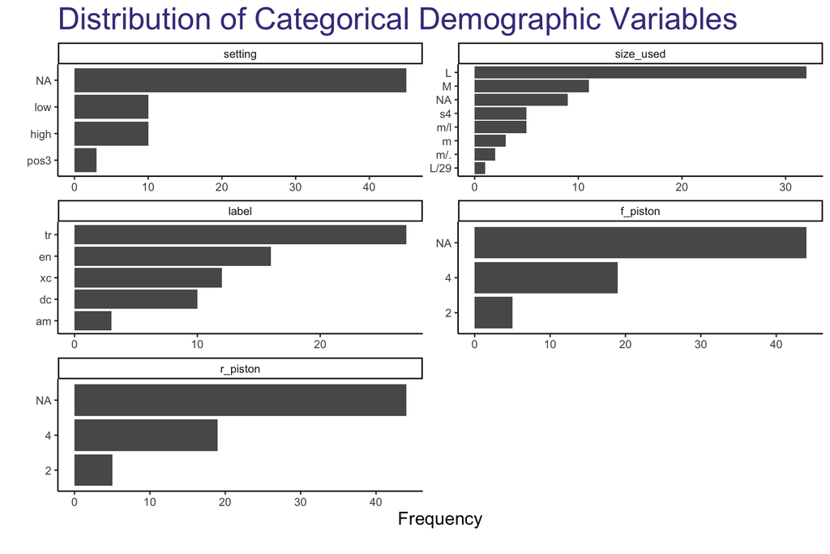

```r
DataExplorer::plot_bar(mtb_data,
                       ggtheme = theme_classic(),
                       title = 'Distribution of Categorical Demographic Variables',
                       theme_config = theme(plot.title = element_text(hjust = 0,
                                                                          color = "slateblue4",
                                                                          size = 24),
                                                plot.subtitle = element_text(hjust = 0, color = "slateblue2", size = 10),
                                                plot.caption = element_text(color = "dark gray", size = 10, face = "italic"),
                                                axis.title.x = element_text(size = 14),
                                                axis.title.y = element_text(size = 14)),
                       maxcat = 10,
                       ncol = 2)
```

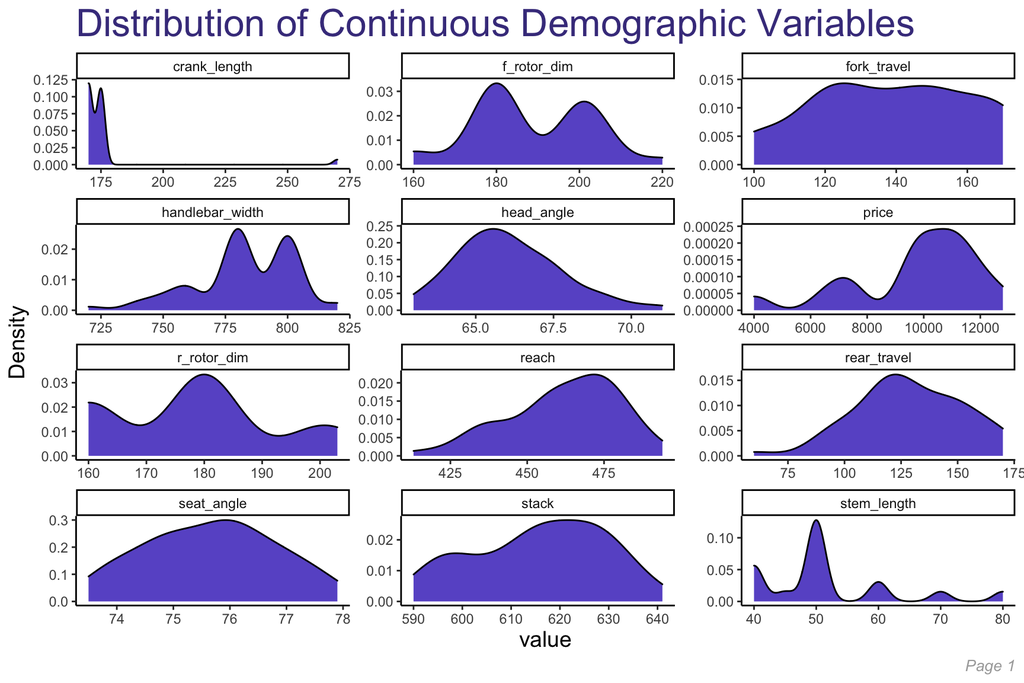

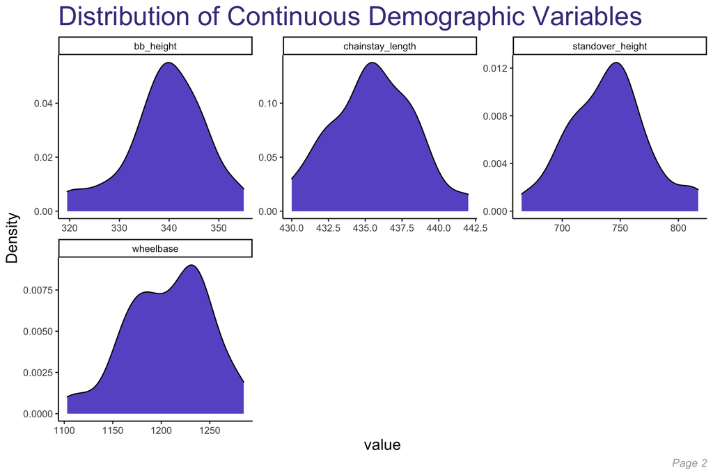

```r
DataExplorer::plot_density(mtb_data,
                             ggtheme = theme_classic(),
                             title = 'Distribution of Continuous Demographic Variables',
                             geom_density_args = list(fill = 'slateblue'),
                             theme_config = theme(plot.title = element_text(hjust = 0,
                                                                                color = "slateblue4",
                                                                                size = 24),
                                                      plot.subtitle = element_text(hjust = 0, color = "slateblue2", size = 10),
                                                      plot.caption = element_text(color = "dark gray", size = 10, face = "italic"),
                                                      axis.title.x = element_text(size = 14),
                                                      axis.title.y = element_text(size = 14)),
                             ncol = 3)
```

## Average bikes by flip-chip setting

```r
# Split data based on setting vs. no setting
no_setting <- mtb_data %>%
  filter(is.na(setting))
setting <- mtb_data %>%
  filter(!is.na(setting))

mean_by_setting <- aggregate(setting[,-3], list( setting$model), FUN=mean)
mean_by_setting$model <- mean_by_setting$Group.1
mean_by_setting <- mean_by_setting[,-1]

no_setting <- no_setting[,-3]

new_mtb_data <- rbind(mean_by_setting, no_setting)
```

# Variation Amongst Featureset

The first thing we’ll do is look to see if any of the features in our dataset are better at explaining the variation amongst the different bikes than other features. That is, it’s completely possible that two features are similar and don’t have much variation in them, even across some of the different bike categories. To do so, we’ll:

1. Look for highly correlated features and flag these for potential removal;
2. Run Principal Component Analysis (PCA) to see if certain features are better at explaining the variation in our data better than others.

## 1. Correlation

First, let’s take a look at our most highly correlated features. We’ll use the `corrplot()` function to better order the highly correlated features by the angular order of their eigenvectors.

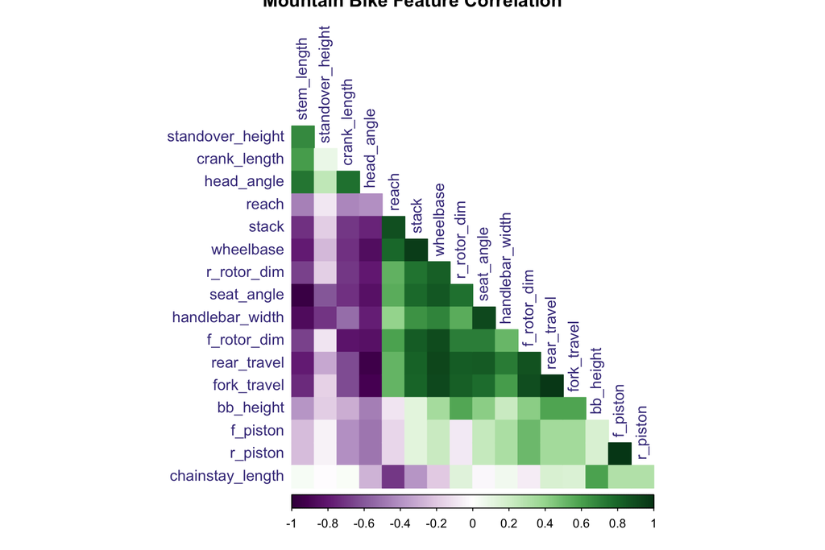

```r
mtb_correlation <- mtb_data %>%
  # Get rid of price for now
  select(-price) %>%
  # Select our variables of interest
  select_if(is.numeric) %>%
  # Remove rows with NAs in them
  # drop_na() %>%
  # Build our correlation matrix, such that missing values are handled by casewise deletion
  cor(use = 'complete.obs')

# Convert our results into a tibble for easier manipulation
mtb_correlation_df <- mtb_correlation %>%
  as_tibble() %>%
  mutate(variable = colnames(mtb_correlation)) %>%
  relocate(variable, everything())

# Build our correlation plot, using the angular order of the eigenvectors
corrplot(mtb_correlation,
         diag = F,
         col = COL2('PRGn'),
         tl.col = 'slateblue4',
         type = 'lower',
         method = 'color',
         order = 'AOE',
         title = 'Mountain Bike Feature Correlation'
         )
```

In all, here are the most highly correlated variables (i.e. variables which have a correlation above .95 or below -.95):

```r
mtb_correlation_df %>%
  pivot_longer(-variable,
               names_to = 'correlated_variable',
               values_to = 'correlation') %>%
  filter(variable != correlated_variable) %>%
  filter((correlation > .95) | (correlation < -.95)) %>%
  pander()
```

| variable | correlated_variable | correlation |
| --- | --- | --- |
| rear_travel | fork_travel | 0.9818 |
| fork_travel | rear_travel | 0.9818 |
| f_piston | r_piston | 1 |
| r_piston | f_piston | 1 |
| seat_angle | stem_length | -0.9508 |
| stem_length | seat_angle | -0.9508 |
| stack | wheelbase | 0.9686 |
| wheelbase | stack | 0.9686 |

For now, we’ll opt to include everything. But later on, as we analyze the importance of different features, we’ll look to remove some of the above variables first.

## 2. PCA

Next, we’ll apply PCA to our dataset. In so doing, we’ll have to center and scale our data given how different the ranges are for certain measurements. Let’s take a look at our 4 principal components which explain the largest proportion of variance in the data:

```r
mtb_no_null <- mtb_data %>%
                select(-price) %>%
                select_if(is.numeric) %>%
                bind_cols(label = mtb_data$label) %>%
                drop_na()

mtb_pca <- prcomp(mtb_no_null %>% select(-label),
                  center = TRUE,
                  scale. = TRUE)

# Put our summary results into a dataframe
mtb_pca_df <- tibble(variable = c('Standard Deviation', 'Proportion of Variance', 'Cumulative Proportion')) %>%
  bind_cols(summary(mtb_pca)$importance)

mtb_pca_df %>%
  # Only display the first 5 columns
  select(c(variable:PC4)) %>%
  pander()
```

| variable | PC1 | PC2 | PC3 | PC4 |
| --- | --- | --- | --- | --- |
| Standard Deviation | 3.126 | 1.665 | 1.329 | 1.252 |
| Proportion of Variance | 0.5748 | 0.1631 | 0.1039 | 0.09223 |
| Cumulative Proportion | 0.5748 | 0.7379 | 0.8418 | 0.934 |

We can see that, actually, starting at our $3^{\text{rd}}$ principal component, nearly 84.2% of the data’s variation is properly explained. Let’s take a look at our top 2 principal components:

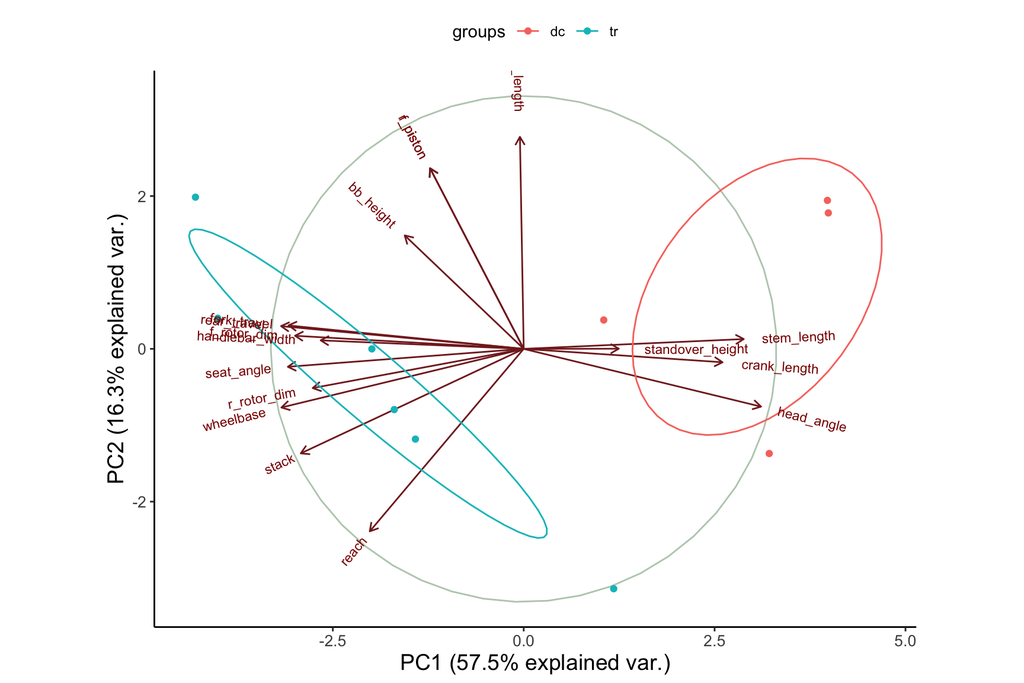

```r
pacman::p_load(devtools)
install_github("vqv/ggbiplot")
pacman::p_load(ggbiplot)
g <- ggbiplot(mtb_pca,
              obs.scale = 1,
              var.scale = 1,
              groups = mtb_no_null$label,
              ellipse = TRUE,
              circle = TRUE,
              ellipse.prob = .5)
# g <- g + scale_color_discrete(name = '')
g <- g + theme(legend.direction = 'horizontal',
               legend.position = 'top')
print(g)
```